# LDA and KNN Classifier Demonstration

## LDA Demonstration

- Use `wine.data` from UCI.
- Use `LinearDiscriminantAnalysis` from `sklearn`

### Discriminant Analysis

#### Background

When we label the data set according to the classification outcome, we may hypothesize that each sub-data set is generated from certain type of probability distributions. Discriminant analysis is a statistical technique which classifies by determining the probability distributions of all classes based on the data.

To be more precise, let's consider a simulated example, performing binary classification based on a numerical feature.

```python
from scipy import stats
import pandas as pd
import numpy as np
#### Creating the Data

end = 30
len_0 = 70
len_1 = 70
color_0 = 'r'
color_1 = 'g'

np.random.seed(108)
x_0 = stats.gamma(9, 0.5).rvs(len_0)
x_1 = stats.norm(15, 6).rvs(len_1)
y   = np.array([color_0]*len_0 + [color_1]*len_1)  #  first len_0 of class r, the next len_1 of class g
```

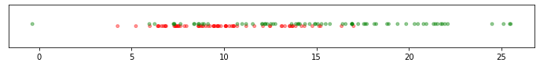

```python
#### Visualize the Data
import matplotlib.pyplot as plt
plt.figure(figsize=(12, 1))
plt.ylim(-0.1, .1)
plt.yticks([])
scatter_kwargs = dict(color=y, s=15, alpha=0.4)
plt.scatter(x=np.concatenate([x_0, x_1]), y=[0]*len_0 + [0.01]*len_1, **scatter_kwargs)
plt.show()
```

If we found two new observations (at 12 and 20), which class do you think they belong to?

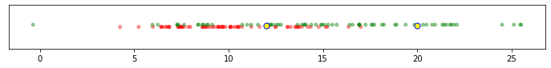

```python
plt.figure(figsize=(12, 1))
plt.ylim(-0.1, .1)
plt.yticks([])
plt.scatter(np.concatenate([x_0, x_1]), [0]*len_0 + [0.01]*len_1, **scatter_kwargs)
yellow_kwargs = dict(c='yellow', s=50, edgecolors='b')
plt.scatter(20, 0.005, **yellow_kwargs)
plt.scatter(12, 0.005, **yellow_kwargs)
plt.show()
```

In the density plot below, we see that when x=20, the red and green classes have dramatically different probabilities. How about when x=12?

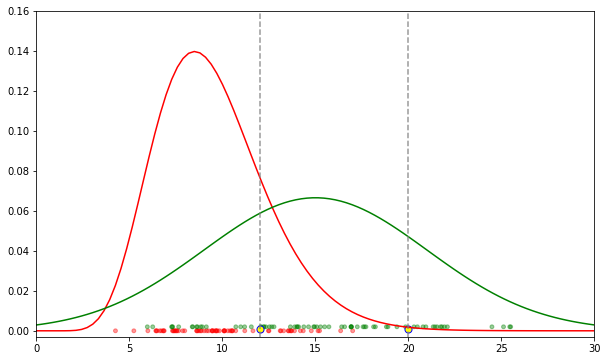

```python
pdf_0 = stats.gamma(9, 0.5).pdf
pdf_1 = stats.norm(15, 6).pdf

lin_sp = np.linspace(start=0, stop=end, num=100)
plt.figure(figsize=(10, 6))
plt.plot(lin_sp, pdf_0(lin_sp), color=color_0)
plt.plot(lin_sp, pdf_1(lin_sp), color=color_1)
plt.scatter(np.concatenate([x_0, x_1]), [0]*len_0 + [0.002]*len_1, **scatter_kwargs)
plt.ylim(-0.003, 0.16)
plt.xlim(0, 30)
yellow_kwargs = dict(c='yellow', s=50, edgecolors='b')
plt.scatter(20, 0.001, **yellow_kwargs)
plt.scatter(12, 0.001, **yellow_kwargs)
line_kwargs = dict(ls='--', color= 'grey', alpha=0.8)
plt.axvline(x=20, **line_kwargs)
plt.axvline(x=12, **line_kwargs)
plt.show()
```

We have found that

$$ \text{ }\\ p(X=x \ | \ Y=k) \text{ for each class k} $$

and the final goal of classification is to compute

$$ \text{ }\\ P(Y=k \ | \ X =x ) \text{ for each class k} $$

But the major question is how do we relate **two kinds** of conditional probabilty?

We can use use **Bayes Thorem** to relate two probabiltiis:

$$ P(Y=k \ | \ X=x) = \frac{p(X=x \ | \ Y=k) P(Y=k)}{\sum_{l}p(X=x \ | \ Y=l) P(Y=l)} $$

Another question?

- How do we estimate the prior proability for class k, $P(Y=k)$, and $p(X=x \ | \ Y=k)$?
  - The prior probabiity is $\frac{n_k}{n}$ where $n_k$ is the number of observations in class k and $n$ is the total number of observations.
  - $p(X=x \ | \ Y=k)$ estimation is not trival as different models result in different types of classifieres (e.g., LDA)

**Linear Discriminant Analysis (LDA)** assumes that the standard deviation is the same for each class. In one dimensional case, this means that the distribution for each class $k \text{ is}$ $$ p(X=x \ | \ Y=k) = \frac{1}{\sqrt{2\pi}\sigma}exp\big[{-\frac{1}{2}\big(\frac{x-\mu_k}{\sigma}\big)^2}\big] $$

With visualization, this means that the **width** of the distribution for each class remains the same. From MLE, we can decide $\mu$ and $\sigma$.

When we move to *d-higher space*, we still need to find d-dimentional vector **$\mu$** and the covariance $d\times$ matrix $\Sigma$: $$ N(\mu, \Sigma)(x) = \frac{1}{(2\pi)^{d/2}|\Sigma|^{1/2}}exp\big[{-\frac{1}{2}(x-\mu)^T\Sigma^{-1}(x-\mu)}\big] $$

**LDA** can be used as a technique for feature extraction to increase the computation efficiency and reduce the degree of overfitting due to the curse of dimensionality in non-regularized models. The goal is to find the feature subspace that optimizes class separability.

#### Question 5 Tips

The sudo code of LDA is

1. Standardize the d-dimentaional dataset (d is the number of features)
2. For each class, compute the d-dimentional mean vector.
3. Construct the between-class matrix $S_B$ and the within-in class scatter matrix $S_w$
   - $S_w=\sum_{i=1}^{c} S_i$ where $S_i=\sum_{x\in D_i}^{c}(x-\mu_i)(x-\mu)^T$
   - $S_B=\sum_{i=1}^c n_i(m_i-m)(m_i-m)^T$ where $m$ is the overall mean.
4. Compute the eigenvectors and corresponding eigenvalues of the matrix $S_w^{-1}S_B$.
   - Use`numpy.linag.eig()` or similar.
5. Sort thee eigenvalues by decreasing order to rank the corresponding egenvectors.
6. Choose the $k$ eignvectors that correspond to the $k$ largest eigenvalues to construct a $d\times k-$dimentional transformation matrix $W$: the eigenvectors are the column of this matrix.
   - Use `numpy.hstack()`or somthing similar.
7. Project the samples onto the new feature subspace using the transformation matrix $W$.
   - $X'=XW$

#### Examples using `LinearDiscriminantAnalysis`

##### Feature Space Transformation Example

###### `Logistic Regression` is used for the classification.

```python
df_wine=pd.read_csv('wine.data',header=None)
```

```python
df_wine.head(4)
```

|  | 0 | 1 | 2 | 3 | 4 | 5 | 6 | 7 | 8 | 9 | 10 | 11 | 12 | 13 |
| --- | --- | --- | --- | --- | --- | --- | --- | --- | --- | --- | --- | --- | --- | --- |
| 0 | 1 | 14.23 | 1.71 | 2.43 | 15.6 | 127 | 2.80 | 3.06 | 0.28 | 2.29 | 5.64 | 1.04 | 3.92 | 1065 |
| 1 | 1 | 13.20 | 1.78 | 2.14 | 11.2 | 100 | 2.65 | 2.76 | 0.26 | 1.28 | 4.38 | 1.05 | 3.40 | 1050 |
| 2 | 1 | 13.16 | 2.36 | 2.67 | 18.6 | 101 | 2.80 | 3.24 | 0.30 | 2.81 | 5.68 | 1.03 | 3.17 | 1185 |
| 3 | 1 | 14.37 | 1.95 | 2.50 | 16.8 | 113 | 3.85 | 3.49 | 0.24 | 2.18 | 7.80 | 0.86 | 3.45 | 1480 |

```python
from sklearn.model_selection import train_test_split
```

```python
X, y = df_wine.iloc[:,1:].values, df_wine.iloc[:,0].values
```

```python
X_train, X_test, y_train, y_test = train_test_split(X, y, test_size=0.3, stratify=y, random_state=0)
```

```python
from sklearn.preprocessing import StandardScaler
sc=StandardScaler()
X_train_std=sc.fit_transform(X_train)
X_test_std=sc.transform(X_test)
```

```python
from sklearn.discriminant_analysis import LinearDiscriminantAnalysis as LDA
```

```python
lda=LDA(n_components=2)
```

```python
X_train_lda=lda.fit_transform(X_train_std, y_train)
```

```python
from sklearn.linear_model import LogisticRegression
```

```python
lr=LogisticRegression()
Ir=lr.fit(X_train_lda,y_train)
```

```python
from matplotlib.colors import ListedColormap

def plot_decision_regions(X,y,classifier, resolution=0.02):
    #Setup marker generator and color map
    markers=('s','x','o','^','v')
    colors=('red','blue','lightgreen','gray','cyan')
    cmap=ListedColormap(colors[:len(np.unique(y))])

    #plot the decision surface
    x1_min, x1_max = X[:,0].min()-1,X[:,0].max()+1
    x2_min, x2_max = X[:,1].min()-1,X[:,1].max()+1
    xx1, xx2 = np.meshgrid(np.arange(x1_min, x1_max, resolution),
                          np.arange(x2_min, x2_max, resolution))
    Z=classifier.predict(np.array([xx1.ravel(),xx2.ravel()]).T)
    Z=Z.reshape(xx1.shape)
    plt.contourf(xx1, xx2, Z, alpha=0.4, cmap=cmap)
    plt.xlim(xx1.min(),xx1.max())
    plt.ylim(xx2.min(),xx2.max())

    #plot class samples
    for idx, cl in enumerate(np.unique(y)):
        plt.scatter(x=X[y==cl,0], y=X[y==cl,1],alpha=0.6,
                   c=cmap(idx), edgecolor='black',marker=markers[idx], label=cl)
```

[output not shown]

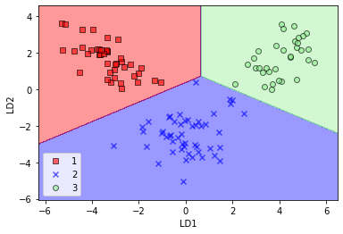

```python
plot_decision_regions(X_train_lda,y_train,classifier=lr)
plt.xlabel('LD1')
plt.ylabel('LD2')
plt.legend(loc='lower left')
plt.show()
```

##### LDA Classification Example Using `IRIS` data.

- You can check if your score meets this score.

HERE I have the score of Iris data.

```python
from sklearn import datasets
iris = datasets.load_iris()
pair = (2, 3)

xlabel = iris.feature_names[pair[0]]
ylabel = iris.feature_names[pair[1]]

iris_x = iris.data[:, pair]
iris_y = iris.target
```

```python
from sklearn import discriminant_analysis
LDA = discriminant_analysis.LinearDiscriminantAnalysis()
LDA.fit(iris.data, iris.target)
LDA.score(iris.data, iris.target)
```

```
0.98
```

# KNN Demonstration

```python
from sklearn.neighbors import KNeighborsClassifier
```

### Parameters

- n_neighbors: number of neighbors.
- p: power parameter for the minkowski metric. $p=1$ is the manhattan distance and the default $p=2$ is the euclidean distance.

```python
knn=KNeighborsClassifier(n_neighbors=5, p=2, metric='minkowski')
```

```python
knn.fit(X_train_std, y_train)
```

```
KNeighborsClassifier(algorithm='auto', leaf_size=30, metric='minkowski',
                     metric_params=None, n_jobs=None, n_neighbors=5, p=2,
                     weights='uniform')
```

```python
knn.score(X_train_std,y_train)
```

```
0.967741935483871
```

```python
knn.predict(X_test_std)
```

```
array([1, 2, 1, 1, 2, 3, 2, 3, 1, 3, 1, 2, 3, 1, 3, 3, 1, 1, 3, 1, 1, 3,
       2, 2, 2, 2, 1, 3, 3, 2, 1, 3, 1, 2, 2, 1, 3, 1, 1, 3, 3, 2, 2, 2,
       1, 2, 2, 3, 2, 3, 2, 2, 1, 1])
```

```python
knn.score(X_test_std,y_test)
```

```
0.9629629629629629
```

```python
knn=KNeighborsClassifier(n_neighbors=23, p=2, metric='minkowski')
knn.fit(X_train_std, y_train)
knn.score(X_test_std,y_test)
```

```
0.9814814814814815
```

The test reslult changed as n increased from 5 to 23. The second part of question 5